# Assignment 2

Author

anonymous

# 1 General information

**Setup**

*This block will only be visible in your HTML output, but will be hidden when rendering to PDF for the submission.* **Make sure that this does not get displayed in the PDF!**

This is the template for assignment 2. You can download the [qmd-file](https://raw.githubusercontent.com/avehtari/BDA_course_Aalto/gh-pages/assignments/template2.qmd) or copy the code from this rendered document after clicking on `</> Code` in the top right corner.

**Please replace the instructions in this template by your own text, explaining what you are doing in each exercise.**

The following will set-up `markmyassignment` to check your functions at the end of the notebook:

```r
library(markmyassignment)
assignment_path = paste("https://github.com/avehtari/BDA_course_Aalto/",
"blob/master/assignments/tests/assignment2.yml", sep="")
set_assignment(assignment_path)
```

```
Assignment set:
assignment2: Bayesian Data Analysis: Assignment 2
The assignment contain the following (3) tasks:
- beta_point_est
- beta_interval
- beta_low
```

The following installs the `aaltobda` package:

```r
options(repos = list(CRAN="http://cran.rstudio.com/"))
#| cache: true
# Caching should be fine here
install.packages("remotes")
remotes::install_github("avehtari/BDA_course_Aalto", subdir = "rpackage", upgrade="never")
```

# 2 Inference for binomial proportion

**Loading the library and the data.**

```r
library(aaltobda)
data("algae")
# The data are now stored in the variable `algae`.
# These are the values for the prior required in the assignment
prior_alpha = 2
prior_beta = 10
```

The below data is **only for the tests**, you need to change to the full data `algae` when reporting your results.

```r
algae_test <- c(0, 1, 1, 0, 0, 0)
```

## 2.1 (a)

$$\text{likelihood:} p(y|\pi) \propto \pi^{a} * (1-\pi)^{b}$$
$$\text{prior:} p(\pi) \propto \pi^{\alpha -1}*(1-\pi)^{\beta - 1}$$
$$\text{posterior:} p(\pi|y) \propto Beta(\alpha + y, \beta + n - y)$$

```r
# These are not the actual values for the posterior!
# You will have to compute those from the data!


y = sum(algae)
n = length(algae)

posterior_alpha = prior_alpha + y
posterior_beta = prior_beta + n - y

print(posterior_alpha)
```

```
[1] 46
```

```r
print(posterior_beta)
```

```
[1] 240
```

The posterior will have the following form $\BetaDist(46 , 240)$

## 2.2 (b)

**Keep the below name and format for the functions to work with `markmyassignment`:**

```r
# Useful function: qbeta()

beta_point_est <- function(prior_alpha, prior_beta, data) {
    # Do computation here, and return as below.
    # This is the correct return value for the test data provided above,
    # combined with the prior provided above.
    y = sum(data)
    n = length(data)
    mean = (prior_alpha + y) / (prior_alpha + prior_beta + n)
}
beta_interval <- function(prior_alpha, prior_beta, data, prob = 0.95) {
    # Do computation here, and return as below.
    # This is the correct return value for the test data provided above,
    # combined with the prior provided above.
    y = sum(data)
    n = length(data)

    left_tail = (1-prob)/2
    right_tail =  1 - left_tail

    c(qbeta(left_tail, prior_alpha + y, prior_beta + n - y),
      qbeta(right_tail, prior_alpha + y, prior_beta + n - y))
}
```

The 90% interval for $\pi$ given the data and the beta prior used is 0.1265607, 0.1978177

## 2.3 (c)

**Keep the below name and format for the function to work with `markmyassignment`:**

```r
# Useful function: pbeta()

beta_low <- function(prior_alpha, prior_beta, data, pi_0=0.2) {
    y = sum(data)
    n = length(data)

    pbeta(pi_0, prior_alpha + y, prior_beta + n - y)
}
```

The probability that $\pi$ is lower than 0.2 is 0.9586136

## 2.4 (d)

For this type of data where we have binary output (occurrence or not of some phenomenon) we need to assume that each observation is conditionally independent given the parameter $\pi$, where that probability is equal for each algae measurement.

## 2.5 (e)

**Plot the PDFs here. Explain shortly what you do.**

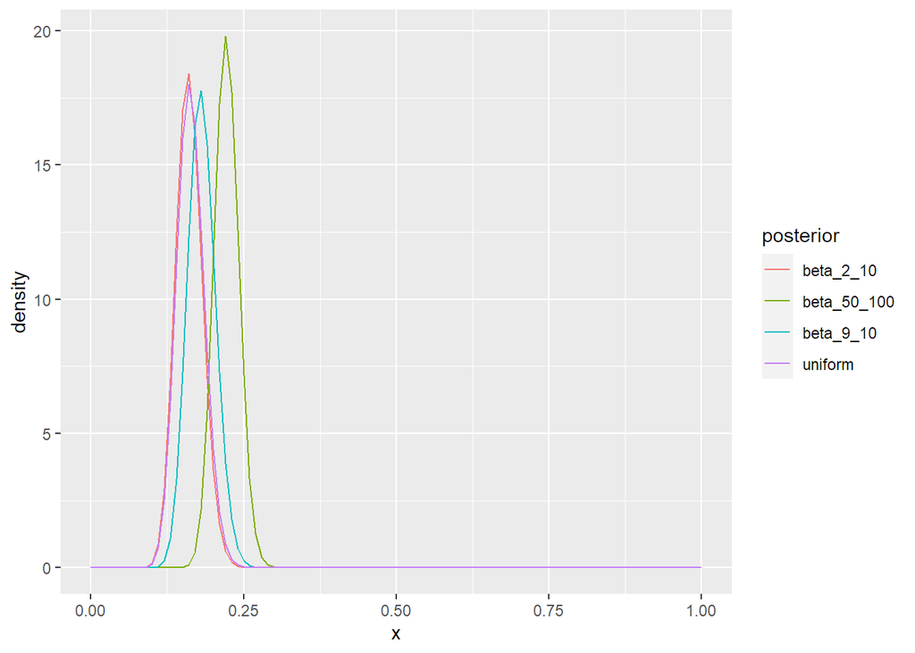

```r
# Useful function: dbeta()
library(ggplot2)
library(dplyr)
library(tidyr)
y =  sum(algae)
n = length(algae)

posterior_alpha_a = 1 + y
posterior_beta_a = 1 + n - y

posterior_alpha_b = 2 + y
posterior_beta_b = 10 + n - y

posterior_alpha_c = 9 + y
posterior_beta_c = 10 + n - y

posterior_alpha_d = 50 + y
posterior_beta_d = 100 + n - y

data = data.frame(x = seq(0,1,0.01))
data = data %>% mutate(uniform = dbeta(x, posterior_alpha_a, posterior_beta_a),
                       beta_2_10 = dbeta(x, posterior_alpha_b, posterior_beta_b),
                       beta_9_10 = dbeta(x, posterior_alpha_c, posterior_beta_c),
                       beta_50_100 = dbeta(x, posterior_alpha_d, posterior_beta_d))

data = data %>% pivot_longer(!x, names_to = "posterior", values_to = "density")


ggplot(data=data) +
  geom_line(aes(x=x, y=density, colour=posterior))
```

**markmyassignment**

*This block will only be visible in your HTML output, but will be hidden when rendering to PDF for the submission.* **Make sure that this does not get displayed in the PDF!**

The following will check the functions for which `markmyassignment` has been set up:

```r
mark_my_assignment()
```

```
v | F W S  OK | Context

/ |         0 | task-1-subtask-1-tests
/ |         0 | beta_point_est()
v |         5 | beta_point_est()

/ |         0 | task-2-subtask-1-tests
/ |         0 | beta_interval()
v |         5 | beta_interval()

/ |         0 | task-3-subtask-1-tests
/ |         0 | beta_low()
v |         5 | beta_low()

== Results =====================================================================
Duration: 0.2 s

[ FAIL 0 | WARN 0 | SKIP 0 | PASS 15 ]
Yay! All done!
```